# Particle filtering lab

15:56 30 October 2015

To illustrate the practical usage of the basic particle filter described in the previous section and to assess its accuracy, we present here a simple example based on 100 observations simulated from a known Dynamic Linear Model. The data are generated from a local level model with system variance $W=1$, observation variance $V=2$, and initial state distribution $N(10,9)$. We save the observations in `y`. Note the use of `dlmForecast` to simulate from a given model.

Generate data:

```r
library("dlm")
mod <- dlmModPoly(1,dV=2,dW=1,m0=10,C0=9)
n <- 100
set.seed(23)
simData <- dlmForecast(mod=mod,nAhead=n,sampleNew=1)
y <- simData$newObs[[1]]
```

Basic particle filter parameters/initialization:

```r
N <- 1000
x <- matrix(NA_real_,n+1,N)
wt<-matrix(NA_real_,n,N)
m0 <- 10
c0 <- 9
m <-  m0
c <-c0
w <- 1
v <- 2
## Initial particles from the prior
x[1,] <- rnorm(N,mean=m[1],sd=sqrt(c[1]))
```

Simple bootstrap filter:

```r
for(i in 1:n)
{
    ## weights from likelihood function
    wt[i,] <- dnorm(y[i],mean=x[i,],sd=sqrt(v))
    ## normalize weights
    wt[i,] <- wt[i,]/sum(wt[i,])
    ## resample particles according to weights and get new particles
    x[i+1,] <- sample(x[i,],N,replace=TRUE,prob=wt[i,])+
        rnorm(N,mean=0,sd=sqrt(w))
}
```

Particle filter using optimal importance density:

```r
N_0 <- N/2
pfOut  <-  matrix(NA_real_, n + 1, N)
wt2 <-  matrix(NA_real_, n + 1, N)
importanceSd  <-  sqrt(drop(W(mod) - W(mod)^2 /(W(mod) + V(mod))))
predSd  <-  sqrt(drop(W(mod) + V(mod)))
## Initialize sampling from the prior
pfOut[1,] <- rnorm(N, mean = m0(mod), sd = sqrt(C0(mod)))
wt2[1,] <- rep(1/N, N)
for (it in 2 : (n + 1)) {
    ## generate particles
    means <- pfOut[it - 1, ] + W(mod)*(y[it - 1] - pfOut[it - 1, ]) /
        (W(mod) + V(mod))
    pfOut[it, ] <- rnorm(N, mean = means, sd = importanceSd)
    ## update the weights
    wt2[it, ] <- dnorm(y[it - 1], mean = pfOut[it-1,],
                       sd = predSd) * wt2[it-1,]
    wt2[it, ] <- wt2[it, ] / sum(wt2[it, ])
    ## resample, if needed
    N.eff <- 1 / crossprod(wt2[it, ])
    if ( N.eff < N_0 ) {
        ## multinomial resampling
        index <- sample(N, N, replace = TRUE, prob = wt2[it, ])
        pfOut[it, ] <- pfOut[it, index]
        wt2[it, ] <- 1/N
    }
}
```

Compare exact (Kalman) filtering distribution with naive and optimal particle (bootstrap) filters:

```r
modFilt<-dlmFilter(y,mod)
KF_mean<-modFilt$m[-1]
KF_sd<-with(modFilt, sqrt(unlist(dlmSvd2var(U.C, D.C))))[-1]
x <- x[-1,]
PF_mean<-sapply(1:n,function(i)
    weighted.mean(x[i,], wt[i,]))
PF_sd<-sapply(1:n, function(i)
    sqrt(weighted.mean((x[i,]-PF_mean[i])^2,wt[i,])))
pfOut<-pfOut[-1,]
wt2<-wt2[-1,]
OPPF_mean<-sapply(1:n,function(i)
    weighted.mean(pfOut[i,], wt2[i,]))
OPPF_sd<-sapply(1:n, function(i)
    sqrt(weighted.mean((pfOut[i,]-OPPF_mean[i])^2,wt2[i,])))
```

Make the plot:

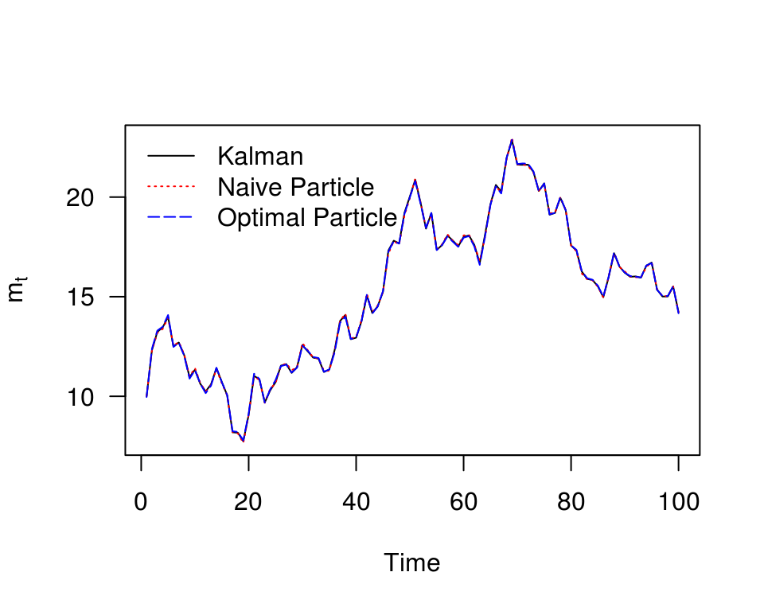

```r
par(mfrow=c(1,1),las=1)
lvec <- c("solid","dotted", "longdash")
cvec <- c("black","red","blue")
labs <- c("Kalman", "Naive Particle","Optimal Particle")
plot.ts(cbind(KF_mean, PF_mean, OPPF_mean),
        plot.type = "s",lty = lvec, col=cvec,
        ylab = expression(m[t]))
legend("topleft", labs,
       lty = lvec, col=cvec, bty = "n")
```

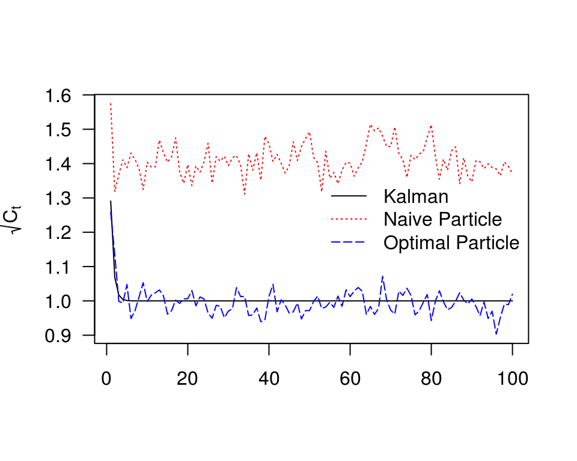

```r
plot.ts(cbind(KF_sd, PF_sd,OPPF_sd), plot.type = "s",
        lty = lvec,
        col=cvec, xlab = "", ylab = expression(sqrt(C[t])))
legend("right", labs,
       lty=lvec, col=cvec, bty = "n")
```

In our implementation of the optimal particle filter we set the number of particles to 1000, and we use the optimal importance kernel as importance transition density. For a Dynamic Linear Model this density is easy to use both in terms of generating from it and for updating the particle weights. To keep things simple, instead of the more efficient residual resampling, we use plain multinomial resampling, setting the threshold for a resampling step to 500, that is, whenever the effective sample size drops below one half of the number of particles, we resample.

## SIR model

As a less-trivial dynamical system, consider the following dynamical system that models an epidemic outbreak in discrete time.

The state of the system is $\{S,I\}$, where $S$ is the current number of susceptible individuals and $I$ is the number of infectious individuals. The *hazard* (probability per unit time) that a susceptible will be infected is $\beta I$, so the probability of infection within a time step $\Delta t$ is $p_I(I) = 1-\exp(-\beta I \Delta t)$. The hazard that an infected individual will recover is $\gamma$ (so $p_R=1-\exp(-\gamma \Delta t)$). Infected individuals are observed with probability $p_C$.

$\begin{split} \textrm{inf(t)} & \sim \textrm{Binom}(p_I, S(t)) \\ \textrm{rec(t)} & \sim \textrm{Binom}(p_R, I(t)) \\ S(t+1) & = S(t)-\textrm{inf}(t) \\ I(t+1) & = I(t)+\textrm{inf}(t)-\textrm{rec}(t) \\ I_{\textrm{obs}}(t) & \sim \textrm{Binom}(p_C, I(t)) \end{split}$

```r
SIR_f1 <- function(xstart,times,params,...) {
    nrep <- ncol(xstart)
    nvars <- nrow(xstart)
    ntimes <- length(times)
    ## pomp wants results to be stored as 3-dimensional array
    ## (state variables x replicates x times)
    ## where the first 'slice' is the starting values
    res <- array(NA,dim=c(nvars,nrep,ntimes),
                 dimnames=list(X=rownames(xstart),
                 rep=1:nrep,time=times))
    res[,,1] <- xstart
    ## in pomp, xstart, params are provided as _matrices_.
    ## if we want to use with() magic we need to transpose
    ## them and then turn them into data frames ...
    ff <- function(x) as.data.frame(t(x))
    for (i in 2:ntimes) {
        res[,,i] <- with(c(ff(res[,,i-1]),ff(params)), { ## R magic
                    infprob      <- 1-exp(-beta*I/N*dt)
                    recoveryprob <- 1-exp(-gamma*dt)
                    newinf     <- rbinom(nrep,prob=infprob,size=S)
                    newrecover <- rbinom(nrep,prob=recoveryprob,size=I)
                    ## combine in same orientation as xstart ...
                    rbind(S=S-newinf,I=I+newinf-newrecover,R=R+newrecover,
                          incid=newinf)
                })
    }
  return(res)
}

params1 <- c(beta=2,gamma=1,dt=1,N=50,pC=0.5,I.0=0.02)
X0 <- c(S=49,I=1,R=0,incid=0)

SIR_obslik <- function(y,x,t,params,log=FALSE,...)  {
    d <- with(as.list(c(x,params)),
              dbinom(y,incid,prob=pC,log=log)
              )
    ## if (any(is.na(d))) browser()
    return(d)
}
SIR_obslik(0,X0,t=0,params1)
```

```
## [1] 1
```

Run a simulation:

```r
set.seed(101)
nt <- 100
ss <- SIR_f1(cbind(X0),times=1:nt,params=cbind(params1))
## ss is returned as a 2x1x100 array; more convenient as 100x2 matrix
Xmat <- t(ss[,1,])
obsvals <- rbinom(100,prob=params1["pC"],size=Xmat[,"incid"])
```

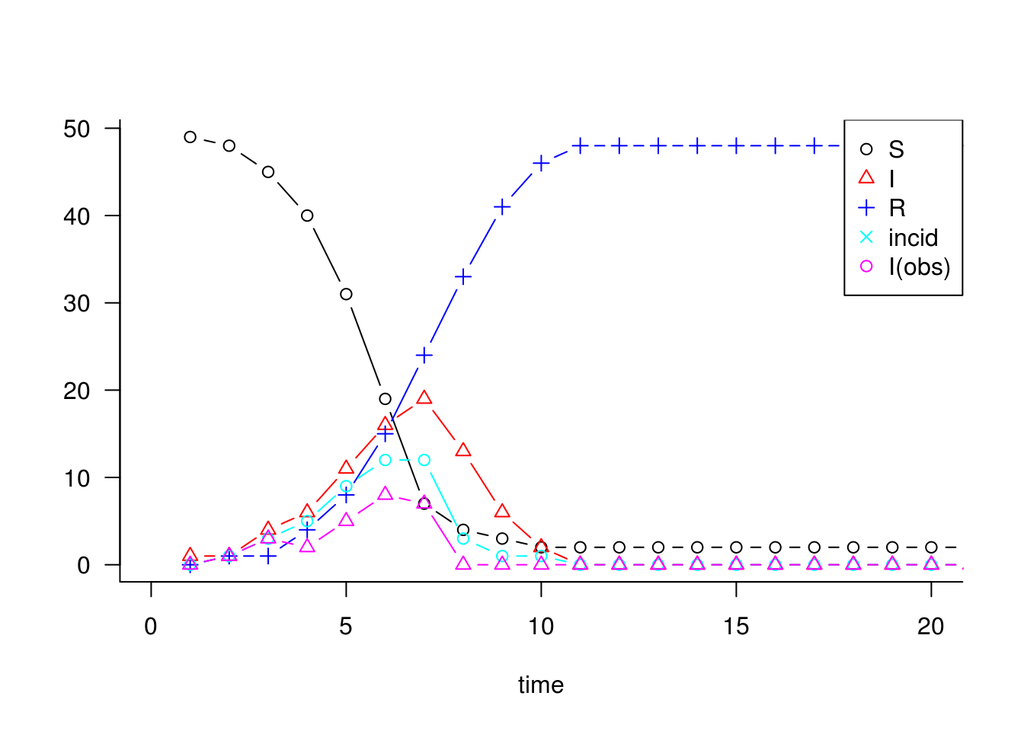

```r
par(las=1,bty="l")
colvec <- c(1,2,4,5,6)
matplot(cbind(Xmat,obsvals),type="b",col=colvec,lty=1,
        pch=1:3,
        xlab="time",ylab="",
        xlim=c(0,20))
legend("topright",col=colvec,pch=1:4,c("S","I","R","incid","I(obs)"))
```

## iterated filtering etc.

To use `pomp` for iterated filtering we need just a little bit more machinery (most of the hard part was done in setting up the simulation function in the weird way we did, which was to enable `pomp`-compatibility …)

```r
library("pomp")
transfun <- function(params,...) {
    params[c("beta","gamma")] <- log(params[c("beta","gamma")])
    params[c("pC","I.0")] <- qlogis(params[c("pC","I.0")])
    return(params)
}
transfun_inv <- function(params,...) {
    params[c("beta","gamma")] <- exp(params[c("beta","gamma")])
    params[c("pC","I.0")] <- plogis(params[c("pC","I.0")])
    return(params)
}
initfun <- function(params,t0,...) {
    with(as.list(params),
     {
         I0 <- ceiling(I.0*N)
         c(S=N-I0,I=I0)
     })}
```

```r
P1 <- pomp(data=obsvals,times=1:length(obsvals),
           t0=0,rprocess=SIR_f1,dmeasure=SIR_obslik,
           toEstimationScale=transfun,
           fromEstimationScale=transfun_inv,
           initializer=initfun
)
```

```r
system.time(m1 <- mif2(P1, Nmif = 10, start=params1, transform=TRUE,
     Np=1000, rw.sd(beta=0.1,gamma=0.1,pC=0.1),
     cooling.fraction.50=0.1))
```

```
##    user  system elapsed
##  30.590   0.108  30.741
```

```r
p1 <- pfilter(m1)  ## final filtering step
```

I picked the tuning parameters `rw.sd` and `cooling.fractions` more or less arbitrarily … now can (begin to) use `plot(m1)` to look at convergence diagnostics …

```r
coef(p1)
```

```
##       beta      gamma         dt          N         pC        I.0
##  1.1761578  2.2951782  1.0000000 50.0000000  0.5093891  0.0200000
```

## With Csnippets

It turns out we can take this almost directly from Ed Ionides and Aaron King’s [dynamic models/Euler’s method tutorial](http://kingaa.github.io/sbied/stochsim/stochsim.html).

**Not working yet**:

```r
SIR_f1C <- Csnippet("
  double newinf = rbinom(S,1-exp(-beta*I/N*dt));
  double newrecover = rbinom(I,1-exp(-gamma*dt));
  S -= newinf;
  I += newinf-newrecover;
  R += newrecover;
  incid = newinf;
")
P1C <- pomp(data=obsvals,times=1:length(obsvals),
            t0=0,rprocess=euler.sim(SIR_f1C,delta.t=1),
            dmeasure=SIR_obslik,
            statenames=names(X0),
            paramnames=names(params1[1:4]),
            toEstimationScale=transfun,
            fromEstimationScale=transfun_inv,
            initializer=initfun
)
```